# A performance model for early cognitive development

Michael C. Frank

Human beings begin their lives as helpless infants yet quickly become children who are able to perceive, act, and communicate. External, physical differences account for only a small amount of this fundamental change: Without a mature mind, a mature body cannot navigate the world. Thus, the fundamental question of developmental psychology is how these external behavioral differences are enabled by internal processes of developmental change.

Identifying these processes is a fundamental and outstanding challenge, for two reasons. First, because they are emergent features of our mental processes and how they interact with external stimuli, they are by definition unobservable. Our best attempts can yield hypothesized computational descriptions (Elman 1998; Tenenbaum et al. 2011). Second, they operate over developmental timescales. While such timescales can be observed longitudinally, such observations are necessarily correlational and hence confounded with other factors. In contrast, controlled, laboratory interventions that allow strong causal inference are typically limited to the timescale of minutes or hours rather than days, weeks, or months.

In this paper, our aim is to begin to address this challenge. We develop a simple quantitative model of performance limitations for complex, multi-part operations. In a nutshell, the model predicts expected performance for a multi-part operation on the basis of the speed and accuracy of the individual parts. In this sense, it is a highly-abstracted version of previous cognitive architecture models like ACT-R (Anderson 1996).

The goal of this model is to provide a baseline, *null hypothesis* for development. It is clear that *at least* the speed and accuracy of any given cognitive operation change across developmental time. But the consequences of these changes are far from obvious.

> Strong continuity hypothesis: Developmental changes come about as a result of changes in speed and accuracy of psychological processes, rather than in their representational content.

## Model

Our model assumes that nearly every mental process—especially those involved in learning—requires multiple operations. These operations are chained in a sequence. Some examples of such sequences:

- *Word learning*: Follow an agent’s gaze to a target, then associate a word that the agent speaks with the identity of the target.
- *Imitation*: Store an agent’s action, then carry out the same action.
- *Object play*: Search for partially occluded target object, move aside occluder, grasp target object.

As is immediately clear, complex actions are describable at many different grain sizes. We view this as a strength rather than a weaknesses of our framework, which can be applied to units at any grain size.

In this section, we first describe the formal details of the model and then turn to how development should be described.

### Formal details

Consider a set of interacting mental processes. We assume that each of these has a Bernoulli success probability $s_p$. With probability $1-s_p$, they fail. For simplicity, we assume chains where all of the operations have the same probability $s$, though of course in the presence of the appropriate data, we could estimate the failability of individual operations.

We assume that one failure in a series of operations leads to the failure of the chain $c$. Thus, the probability of a sequence of failures is exponential such that $P_{success} = s^{n}$, where $n$ is the length of the chain.

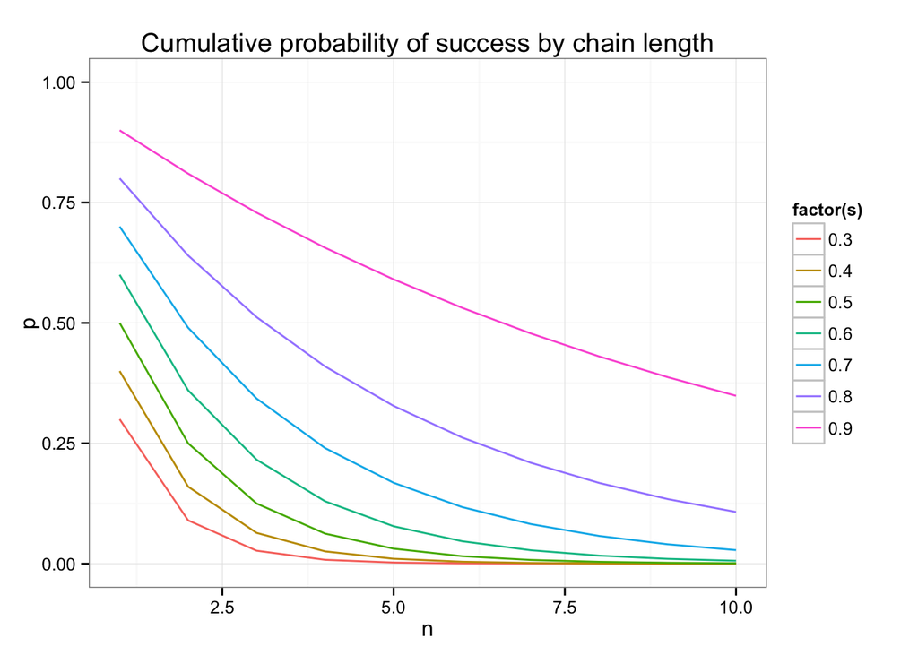

We also associate a time to completion with each operation. We assume that these are “reaction times” and are sampled from a log-normal distribution:

$RT(s_p) \sim exp(N(\mu,\sigma))$

The arithmetic mean of a lognormal is $e^{\mu + \sigma^2/2}$. Unfortunately, there is not a known parametric form for the sum of multiple lognormals. (Fenton 1960) et seq have introduced a varity of approximations for these sums, but here we pursue a simulation approach instead.

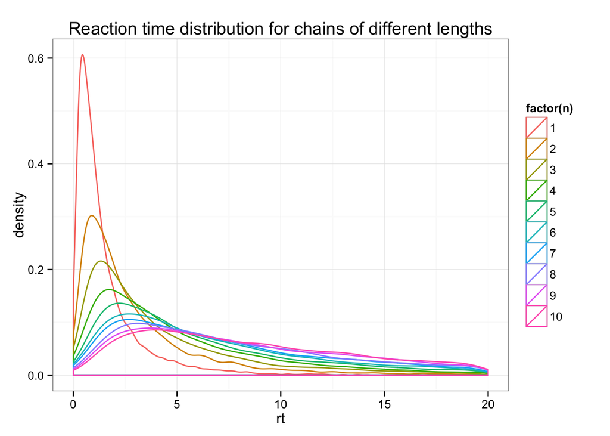

Imagine a time-sensitive operation, e.g. the word learning case above. We consider a temporal threshold $\theta$ such that if the two operations are not completed within this threhold, then there is no possibility of learning. We can now compute the probability that a chain is successful within the appropriate time period for learning.

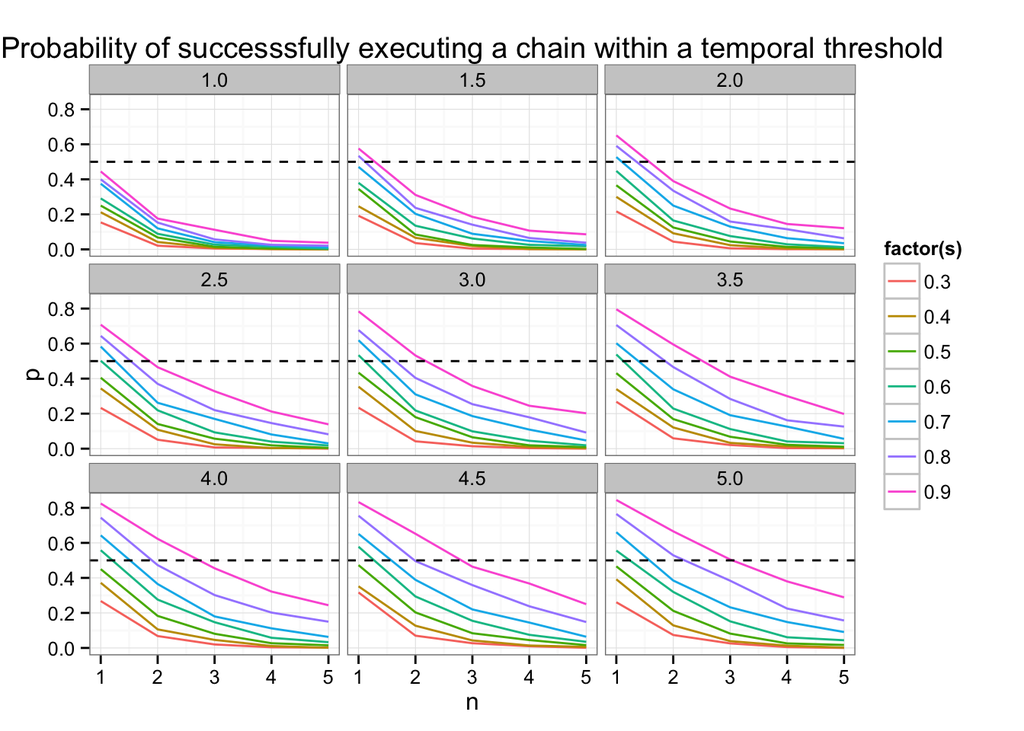

Of course, to be meaningful, these simulations require estimates for the values of $\mu$, $\sigma$, $n$, $s$, and $\theta$. The remainder of the paper attempts to provide a framework for reasoning about and estimating these numbers.

### Development within this model

The two posited capacities in our model are speed and accuracy. It seems clear that, for an individual cognitive operation or set of operations, both of these should change dramatically across development. How does developmental change look for these abilities?

We first consider the development of processing speed. Pioneering work by Kail (see e.g., Kail 1991) describes the developmental trajectory of reaction times for individual tasks. He notes that empirically, the slope of these reaction times follows an exponential, such that

$Y = a + b e^{-ci}$

Where Y is the predicted variable, $a$ is the eventual (adult) asymptote, $b$ is the multiplier for the (infant) intercept, $c$ is the rate of development, and $i$ is age.

We replot the slowing function from Kail (1991):

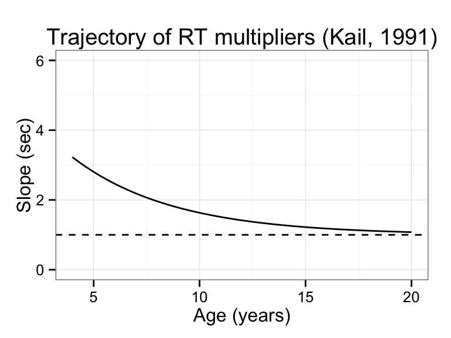

Consider when this model is projected into infancy:

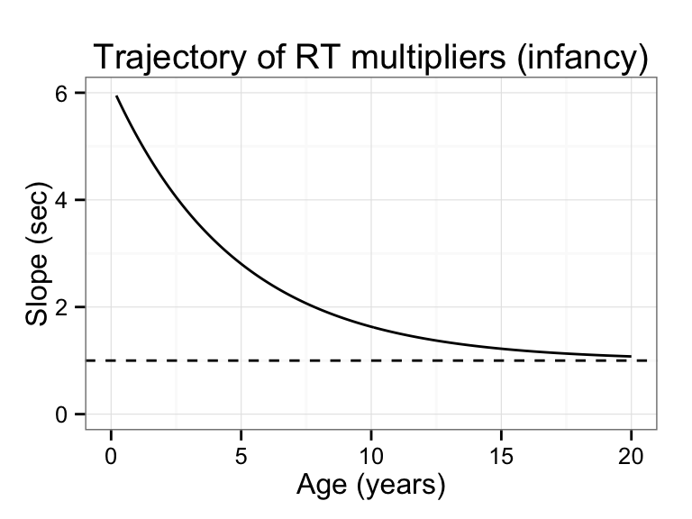

This is a model of RT multipliers. By hypothesis, these multipliers should apply to individual operations or to chains of operations, since times are additive; if the multiplier is constant then it can be factored out.

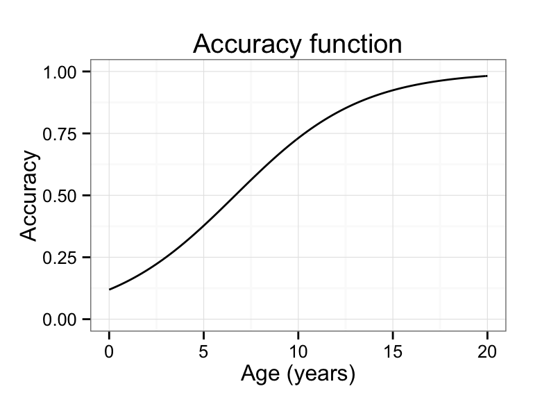

So now let’s generalize these functions so that we can look at their joint effects on performance.

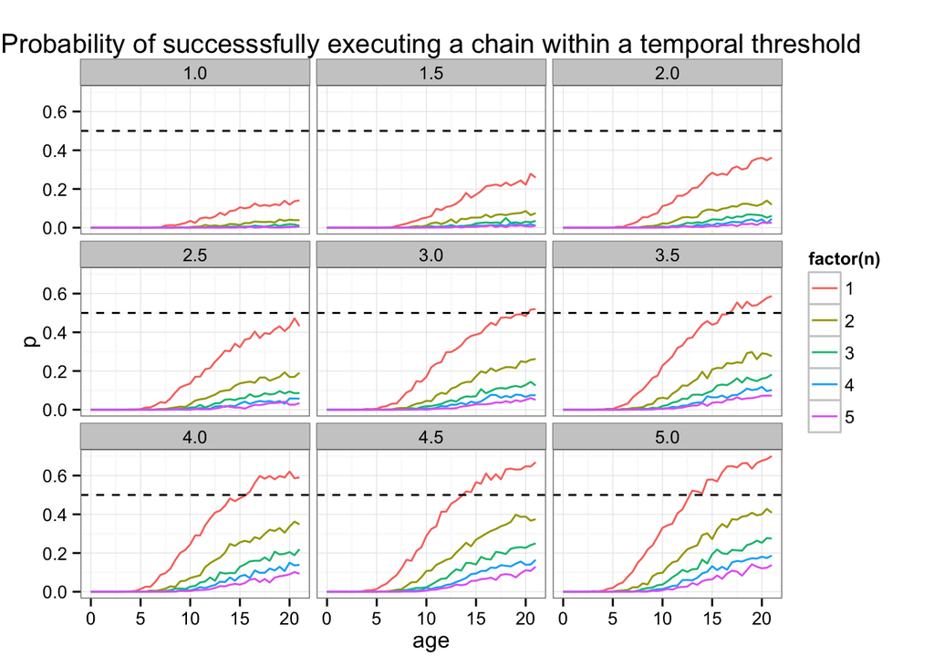

So this is nice, we get a joint yoking of speed and accuracy to age, with the ability to make generalization about the probability of success in chains of length $n$ within a temporal threshold.

To review: we now have a theoretical model that can make predictions about developmental changes in the speed and accuracy of executing chains of cognitive operations. The trouble is that to constrain these predictions, we require quite a bit of external information about changes in RT and accuracy.

## Case Study 1: Early Word Learning

We focus here on learning a word that is presented ostensively via a social cue like gaze or pointing, which we refer to as “social word learning.” For simplicity, we decompose the task of social word learning into two abilities: 1) gaze following, and 2) word recognition. This task analysis is clearly incomplete or incorrect - for example, pointing is not the same as gaze following, and recognition is not the same as learning and retention. But it nevertheless captures some aspects of the task - following a socialcue to a distal target and processing some language associated with that target. And it has the major benefit for our purposes of providing data on development, since each of these tasks is well-studied.

Let’s begin by attempting to estimate developmental changes in the speed of processing a word. Of course there are many factors involved, including the frequency and general familiarity of the word. But the literature on infants’ early language processing generally attempts to select simple, easy words that should be accessible to almost all children, so we can use this literature to get a rough-and-ready estimate of declines in reaction time across ages.

```
## ymax not defined: adjusting position using y instead
```

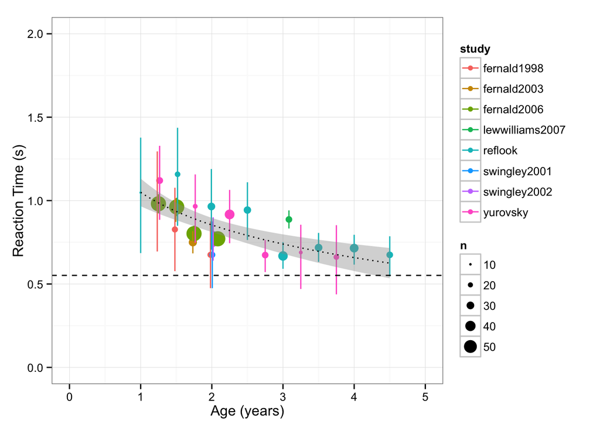

Now fit a Kail curve to these data. Note that this is a simpler analysis - we’re not fitting multipliers on the slope of a mental-rotation function, we’re just fitting multipliers on the actual adult RT. The Kail curve looks almost identical to the log curve we fit to the kid data - although this is partially just that they are both exponential function fits, the asymptote didn’t have to be the same (e.g., didn’t have to be the adult RT).

```
## ymax not defined: adjusting position using y instead
```

[figure not shown]

## Conclusions

- Relationship to other models
- Limitations
- Relationship to neural development
- Relationship to *g* and other measures of intelligence

References

Anderson, John R. 1996. “ACT: A Simple Theory of Complex Cognition.” *American Psychologist* 51 (4). American Psychological Association: 355.

Carey, Susan. 2009. *The Origin of Concepts*. Oxford University Press.

Elman, Jeffrey L. 1998. *Rethinking Innateness: A Connectionist Perspective on Development*. Vol. 10. MIT press.

Fenton, Lawrence F. 1960. “The Sum of Log-Normal Probability Distributions in Scatter Transmission Systems.” *Communications Systems, IRE Transactions on* 8 (1). IEEE: 57–67.

Kail, Robert. 1991. “Developmental Change in Speed of Processing During Childhood and Adolescence.” *Psychological Bulletin* 109 (3). American Psychological Association: 490.

Spelke, Elizabeth S, and Katherine D Kinzler. 2007. “Core Knowledge.” *Developmental Science* 10 (1). Wiley Online Library: 89–96.

Tenenbaum, Joshua B, Charles Kemp, Thomas L Griffiths, and Noah D Goodman. 2011. “How to Grow a Mind: Statistics, Structure, and Abstraction.” *Science* 331 (6022). American Association for the Advancement of Science: 1279–85.